# Final_Ubiquant_ExploratoryAnalysis

## Exploratory Data Analytics - Ubiquant Stock Market

```python
import pandas as pd
import numpy as np
import matplotlib.pyplot as plt
import seaborn as sns
```

```python
data = pd.read_csv("reduced_df.csv")
```

```python
X = data[['f_0','f_1','f_2','f_3','f_4','f_5','f_6','f_7','f_8','f_9','f_10','f_11','f_12','f_13','f_14','f_15','f_16','f_17',
'f_18','f_19','f_20','f_21','f_22','f_23','f_24','f_25','f_26','f_27','f_28','f_29','f_30','f_31','f_32','f_33','f_34','f_35',
'f_36','f_37','f_38','f_39','f_40','f_41','f_42','f_43','f_44','f_45','f_46','f_47','f_48','f_49','f_50','f_51','f_52','f_53',
'f_54','f_55','f_56','f_57','f_58','f_59','f_60','f_61','f_62','f_63','f_64','f_65','f_66','f_67','f_68','f_69','f_70','f_71',
'f_72','f_73','f_74','f_75','f_76','f_77','f_78','f_79','f_80','f_81','f_82','f_83','f_84','f_85','f_86','f_87','f_88','f_89',
'f_90','f_91','f_92','f_93','f_94','f_95','f_96','f_97','f_98','f_99','f_100','f_101','f_102','f_103','f_104','f_105','f_106',
'f_107','f_108','f_109','f_110','f_111','f_112','f_113','f_114','f_115','f_116','f_117','f_118','f_119','f_120','f_121','f_122',
'f_123','f_124','f_125','f_126','f_127','f_128','f_129','f_130','f_131','f_132','f_133','f_134','f_135','f_136','f_137','f_138',
'f_139','f_140','f_141','f_142','f_143','f_144','f_145','f_146','f_147','f_148','f_149','f_150','f_151','f_152','f_153','f_154',
'f_155','f_156','f_157','f_158','f_159','f_160','f_161','f_162','f_163','f_164','f_165','f_166','f_167','f_168','f_169','f_170',
'f_171','f_172','f_173','f_174','f_175','f_176','f_177','f_178','f_179','f_180','f_181','f_182','f_183','f_184','f_185','f_186',
'f_187','f_188','f_189','f_190','f_191','f_192','f_193','f_194','f_195','f_196','f_197','f_198','f_199','f_200','f_201','f_202',
'f_203','f_204','f_205','f_206','f_207','f_208','f_209','f_210','f_211','f_212','f_213','f_214','f_215','f_216','f_217','f_218',
'f_219','f_220','f_221','f_222','f_223','f_224','f_225','f_226','f_227','f_228','f_229','f_230','f_231','f_232','f_233','f_234',
'f_235','f_236','f_237','f_238','f_239','f_240','f_241','f_242','f_243','f_244','f_245','f_246','f_247','f_248','f_249','f_250',
'f_251','f_252','f_253','f_254','f_255','f_256','f_257','f_258','f_259','f_260','f_261','f_262','f_263','f_264','f_265','f_266',
'f_267','f_268','f_269','f_270','f_271','f_272','f_273','f_274','f_275','f_276','f_277','f_278','f_279','f_280','f_281','f_282',
'f_283','f_284','f_285','f_286','f_287','f_288','f_289','f_290','f_291','f_292','f_293','f_294','f_295','f_296','f_297','f_298',
'f_299']]

y = data['target']
```

**We Apply the Concept of Principal Component Analysis to the Dataset in order to reduce the 300 Features to 50 Features. This will help us reduce the dimensions of the Input Features, and ease the process of applying multiple models to the Dataset in order to Compare the Results and Obtain the best Model**

```python
from sklearn.decomposition import PCA

pca = PCA(n_components = 50)
X_new = pca.fit_transform(X)
explained_variance = pca.explained_variance_ratio_
```

```python
X_new = pd.DataFrame(X_new)
y = pd.DataFrame(y)
data = pd.concat([X_new,y],axis=1)
data.head(10)
```

|  | 0 | 1 | 2 | 3 | 4 | 5 | 6 | 7 | 8 | 9 | ... | 41 | 42 | 43 | 44 | 45 | 46 | 47 | 48 | 49 | target |
| --- | --- | --- | --- | --- | --- | --- | --- | --- | --- | --- | --- | --- | --- | --- | --- | --- | --- | --- | --- | --- | --- |
| 0 | 5.930771 | 2.824082 | -6.391417 | -0.642561 | 0.846316 | 0.198980 | 2.039741 | 1.618770 | -2.733506 | -1.212307 | ... | -2.007940 | 1.628662 | 0.241157 | -0.100084 | -2.554118 | 0.011201 | -0.627221 | -0.470128 | -0.666375 | -0.300875 |
| 1 | -1.979082 | 5.205640 | 4.769115 | 1.021418 | -2.399526 | -4.065726 | -0.410048 | -1.588963 | -1.065789 | -0.093744 | ... | -1.406247 | 2.137780 | -0.231313 | 1.770612 | -0.304369 | 1.512396 | 0.919627 | -0.830171 | 0.325942 | -0.231040 |
| 2 | 0.060884 | -0.208156 | -5.462405 | 2.508530 | 3.332347 | -1.066171 | 0.667934 | -0.327424 | -2.105686 | 0.333933 | ... | 0.486018 | -0.368881 | 0.049094 | 0.140143 | 0.304171 | 0.183573 | 1.284293 | -1.388055 | -0.731574 | 0.568807 |
| 3 | -8.785642 | 5.701728 | -2.182945 | -1.501638 | -1.258525 | 0.732001 | 3.611305 | 0.652125 | 0.580285 | -1.092369 | ... | -0.205032 | 0.039889 | 0.277333 | -1.541842 | 1.179722 | -0.394019 | -0.727256 | 0.218874 | 1.443269 | -1.064780 |
| 4 | -13.456921 | -1.051678 | -1.098693 | -2.687385 | -1.377835 | -3.376065 | 3.060878 | 0.418250 | 5.010150 | -1.292009 | ... | -0.137965 | 0.197945 | -0.478897 | -0.612334 | 0.185505 | -0.492317 | 0.707328 | -0.036302 | 0.155449 | -0.531940 |
| 5 | 8.922795 | 0.762759 | -6.022472 | -6.199827 | 1.092391 | -0.642928 | -1.028266 | -0.473390 | -0.076392 | 1.064619 | ... | -0.139460 | 0.833840 | 0.583543 | -1.275726 | -0.906581 | 0.037387 | 0.062450 | 1.394903 | -0.116401 | 1.505904 |
| 6 | -9.385422 | -0.970014 | 2.629263 | -0.920374 | -1.298078 | -1.779595 | 4.558604 | 1.041134 | -0.991810 | 1.403667 | ... | 0.979368 | -0.652847 | -1.038307 | -0.285766 | 0.697676 | -0.868228 | -0.012259 | 0.995066 | 1.521898 | -0.260731 |
| 7 | -3.950835 | 1.634322 | 3.863835 | 2.752713 | 1.266304 | -1.674165 | -1.367761 | -2.863542 | -0.348253 | 1.163306 | ... | -0.830711 | -0.956272 | -0.811298 | 2.072946 | 0.322349 | 0.107293 | -1.443461 | -1.066221 | -0.225511 | -0.469207 |
| 8 | 10.272165 | -12.048630 | 4.985633 | -5.185841 | 5.790271 | 1.853501 | 10.185525 | -7.944356 | 1.768346 | 5.040626 | ... | 2.824415 | 0.303004 | 0.114004 | 2.261560 | 1.525124 | -0.874600 | 0.589227 | 0.709322 | -0.216164 | 0.094525 |
| 9 | -13.123878 | 0.622628 | 2.214304 | -1.619364 | -2.535647 | 0.067408 | 0.808640 | 3.572927 | 2.761413 | -0.042207 | ... | -0.282719 | -1.105133 | 0.490323 | -0.569730 | 0.198101 | 0.868305 | 0.179927 | 0.311260 | 1.133918 | -0.251120 |

10 rows × 51 columns

**The New Dataset Obtained after Reduction of the Dimensions is give Above**

```python
data.info()
```

```
<class 'pandas.core.frame.DataFrame'>
RangeIndex: 4000 entries, 0 to 3999
Data columns (total 51 columns):
 #   Column  Non-Null Count  Dtype
---  ------  --------------  -----
 0   0       4000 non-null   float64
 1   1       4000 non-null   float64
 2   2       4000 non-null   float64
 3   3       4000 non-null   float64
 4   4       4000 non-null   float64
 5   5       4000 non-null   float64
 6   6       4000 non-null   float64
 7   7       4000 non-null   float64
 8   8       4000 non-null   float64
 9   9       4000 non-null   float64
```

[output cut: 43 more lines]

```python
data.describe()
```

|  | 0 | 1 | 2 | 3 | 4 | 5 | 6 | 7 | 8 | 9 | ... | 41 | 42 | 43 | 44 | 45 | 46 | 47 | 48 | 49 | target |
| --- | --- | --- | --- | --- | --- | --- | --- | --- | --- | --- | --- | --- | --- | --- | --- | --- | --- | --- | --- | --- | --- |
| count | 4.000000e+03 | 4.000000e+03 | 4.000000e+03 | 4.000000e+03 | 4.000000e+03 | 4.000000e+03 | 4.000000e+03 | 4.000000e+03 | 4.000000e+03 | 4.000000e+03 | ... | 4.000000e+03 | 4.000000e+03 | 4.000000e+03 | 4.000000e+03 | 4.000000e+03 | 4.000000e+03 | 4.000000e+03 | 4.000000e+03 | 4.000000e+03 | 4000.000000 |
| mean | 1.052491e-16 | 2.371436e-16 | 6.317169e-17 | -2.052802e-16 | -1.011413e-16 | 1.043610e-17 | 1.951772e-16 | 1.430488e-16 | -2.412237e-16 | 6.580847e-17 | ... | -2.208789e-16 | 9.697711e-17 | 3.967660e-16 | 6.243339e-16 | 5.597189e-16 | -3.688716e-17 | -4.696521e-16 | 4.357625e-18 | -5.289727e-16 | -0.026119 |
| std | 8.639899e+00 | 4.891792e+00 | 3.993423e+00 | 3.571303e+00 | 3.186306e+00 | 2.898071e+00 | 2.590288e+00 | 2.214837e+00 | 2.175826e+00 | 2.036805e+00 | ... | 1.017721e+00 | 9.905358e-01 | 9.885335e-01 | 9.720861e-01 | 9.640381e-01 | 9.581234e-01 | 9.385330e-01 | 9.292261e-01 | 9.159119e-01 | 0.938427 |
| min | -1.654847e+01 | -1.681398e+01 | -1.176662e+01 | -1.955376e+01 | -1.020270e+01 | -1.151606e+01 | -6.848372e+00 | -8.190248e+00 | -6.658143e+00 | -5.638952e+00 | ... | -5.208845e+00 | -5.214630e+00 | -3.905488e+00 | -6.968832e+00 | -5.051113e+00 | -5.246564e+00 | -5.239374e+00 | -4.792478e+00 | -5.232554e+00 | -3.533816 |
| 25% | -6.719304e+00 | -3.191688e+00 | -2.839173e+00 | -2.074523e+00 | -2.191912e+00 | -2.028758e+00 | -1.690625e+00 | -1.400258e+00 | -1.418321e+00 | -1.048579e+00 | ... | -6.373015e-01 | -5.892359e-01 | -6.536322e-01 | -5.972682e-01 | -5.925543e-01 | -5.651667e-01 | -5.939642e-01 | -5.900847e-01 | -5.718270e-01 | -0.599293 |
| 50% | -1.027070e+00 | -1.076588e-01 | -6.417360e-02 | -1.416977e-01 | -1.545250e-01 | -1.793890e-01 | -8.211011e-02 | 3.706215e-03 | -1.587031e-01 | -1.939841e-01 | ... | 1.309451e-02 | -2.063838e-02 | 6.123746e-03 | -1.601771e-02 | 1.008460e-02 | 3.498735e-02 | 3.210461e-03 | -9.561011e-03 | 1.020734e-02 | -0.163023 |
| 75% | 5.706179e+00 | 3.194787e+00 | 2.649876e+00 | 1.873249e+00 | 2.032157e+00 | 1.862257e+00 | 1.613543e+00 | 1.366865e+00 | 1.224433e+00 | 6.740905e-01 | ... | 6.223500e-01 | 5.527913e-01 | 6.415080e-01 | 6.037429e-01 | 6.050462e-01 | 6.029267e-01 | 5.924228e-01 | 5.700348e-01 | 5.717450e-01 | 0.373401 |
| max | 4.190650e+01 | 2.052549e+01 | 1.647855e+01 | 2.308928e+01 | 1.191708e+01 | 1.294227e+01 | 1.442746e+01 | 1.373804e+01 | 1.391239e+01 | 2.119347e+01 | ... | 6.827875e+00 | 1.368076e+01 | 4.862496e+00 | 8.836113e+00 | 5.660672e+00 | 5.304269e+00 | 5.990156e+00 | 4.987436e+00 | 6.382930e+00 | 7.729597 |

8 rows × 51 columns

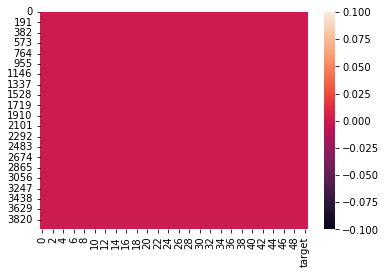

```python
sns.heatmap(data.isnull())
```

```python
data.isnull().sum()
```

```
0         0
1         0
2         0
3         0
4         0
5         0
6         0
7         0
8         0
9         0
10        0
11        0
12        0
13        0
14        0
```

[output cut: 37 more lines]

**We can see that there are no null values present in the data**

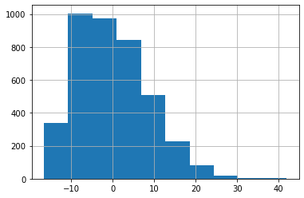

```python
data[0].hist()
```

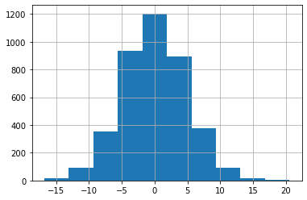

```python
data[1].hist()
```

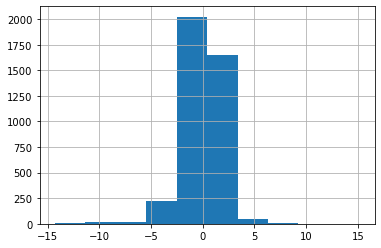

```python
data[10].hist()
```

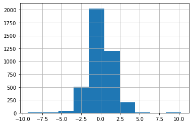

```python
data[15].hist()
```

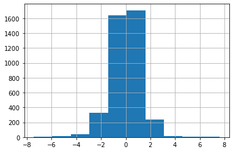

```python
data[25].hist()
```

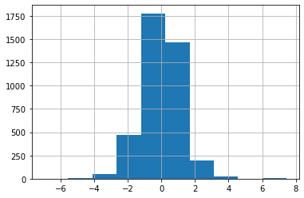

```python
data[28].hist()
```

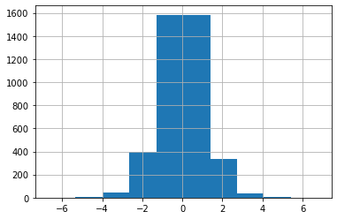

```python
data[30].hist()
```

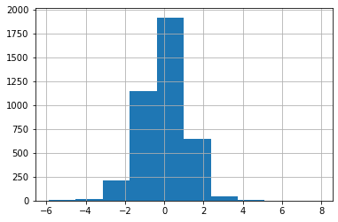

```python
data[33].hist()
```

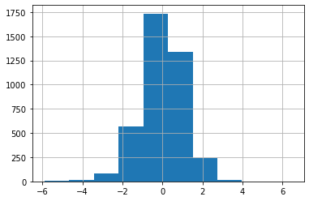

```python
data[36].hist()
```

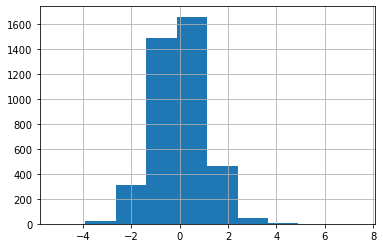

```python
data[38].hist()
```

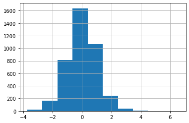

```python
data[40].hist()
```

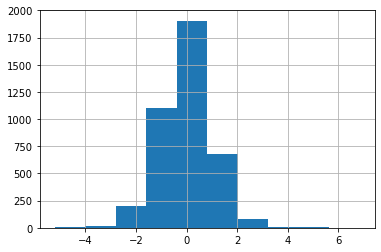

```python
data[41].hist()
```

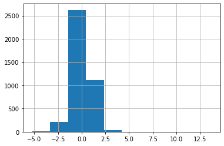

```python
data[42].hist()
```

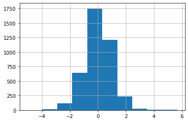

```python
data[45].hist()
```

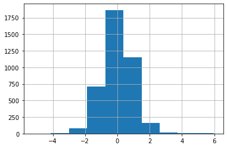

```python
data[47].hist()
```

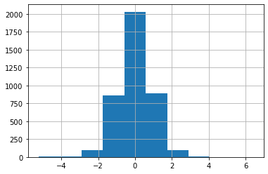

```python
data[49].hist()
```

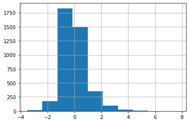

```python
data['target'].hist()
```

X-axis: Class Intervals  
Y-axis: Frequency of the Feature  
These Graphs Depict the distribution of the data and how it is Spread out throughout the Class Intervals. We can see that for Most Features and the Target Feature, majority of the data lies along the Interval of [ -2 , 2 ]

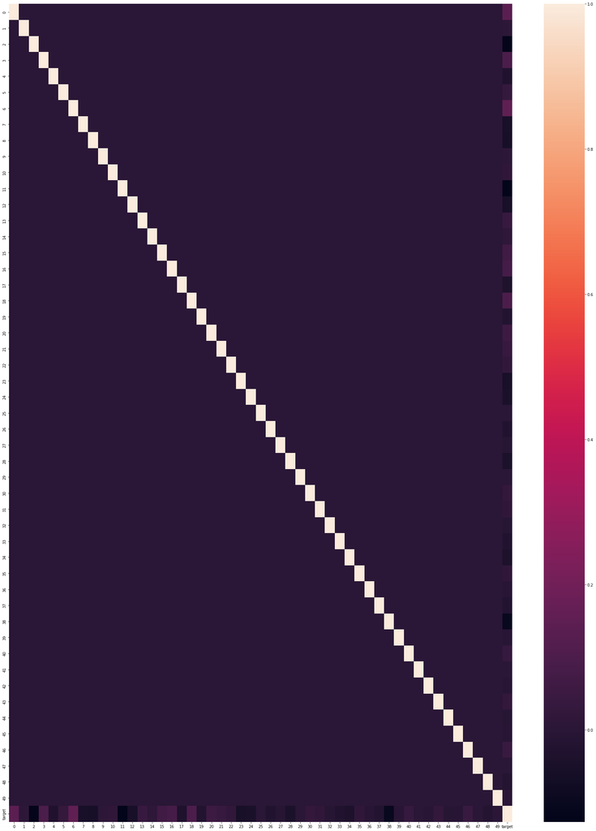

```python
plt.figure(figsize = (30,40))
sns.heatmap(data.corr())
```

```python
data.corr()['target']
```

```
0         0.137214
1         0.008032
2        -0.121504
3         0.095358
4        -0.032559
5         0.027242
6         0.150706
7        -0.056237
8        -0.058486
9         0.008568
10        0.015891
11       -0.126970
12       -0.052534
13        0.035917
14        0.012163
```

[output cut: 37 more lines]

```python
target_corr = pd.DataFrame(data.corr()['target'])
target_corr.head(10)
```

|  | target |
| --- | --- |
| 0 | 0.137214 |
| 1 | 0.008032 |
| 2 | -0.121504 |
| 3 | 0.095358 |
| 4 | -0.032559 |
| 5 | 0.027242 |
| 6 | 0.150706 |
| 7 | -0.056237 |
| 8 | -0.058486 |
| 9 | 0.008568 |

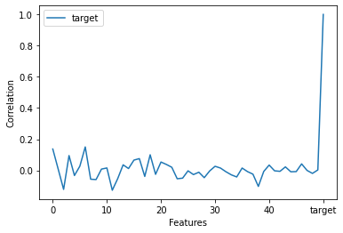

```python
target_corr.plot()
plt.xlabel('Features')
plt.ylabel('Correlation')
```

The X-axis represent the Feature Numbers  
The Y-axis represent the Correlation Values

**The Plot Above shows the Correlation Plot of All the Features with the Target Variable, It is Quite Visible that while some of them have a Positive Correlation there are some features that have a negative Correlation with the Target Variable as well**